# EJEMPLOS: PLANTEAMIENTO Y SOLUCIÓN GRÁFICA DE PROBLEMAS DE PROGRAMACIÓN LINEAL

Investigación de Operaciones - Ingeniería Civil Industrial - ADVANCE

Marcelo Alid-Vaccarezza

2020-07-08

# **EJEMPLO 1.**

Usted fabrica dos tipos de pasteles semanalmente. El pastel $A$ requiere para su elaboración medio kilo de azúcar y $8$ huevos, y tiene un precio de venta de $\$8.000$. El pastel $B$ necesita $1$ kilo de azúcar y $8$ huevos, y tiene un precio de venta de $\$10.000$. En su bodega, le quedan disponibles $10$ kilos de azúcar y $120$ huevos.

1. Plantee el problema como un Problema de Programación Lineal, definiendo claramente las variables de decisión, la función objetivo y las restricciones.
2. Usando el método gráfico, resuelva, analice y concluya.

## SOLUCIÓN.

**Análisis de la información.** Primero se organiza la información en la siguiente tabla.

|  | Pastel A | Pastel B | Disponible |
| --- | --- | --- | --- |
| Azúcar | 0.5 | 1 | 10 |
| Huevos | 8 | 8 | 120 |
| Utilidad | $8000 | $10000 |  |

**Definición de las variables.** Se debe decidir cuántos pasteles $A$ y $B$ se deberán producir para lograr un máximo de utilidad; por lo cual las variables de decisión son:

$$\begin{array}{ll}
x_{1}: \ \text{cantidad de pasteles A a producir por semana.} \\
x_{2}: \ \text{cantidad de pasteles B a producir por semana.}
\end{array}$$

**Modelo matemático completo.** El modelo matemático de programación lineal para queda de la siguiente manera:

$$\begin{array}{ll}
\max Z = 8000x_{1} + 10000x_{2} \\
\text{S.A.} \\
0.5x_{1} + \ \ x_{2} \leq \ \ 10 \ \text{(kilos de azucar)} \\
\ \ \ 8x_{1} + 8x_{2} \leq 120 \ \text{(unidades de huevos)} \\
\qquad \ \ x_{1}, x_{2} \geq \ \ \ 0 \ \text{(no negatividad)}
\end{array}$$

**Gráfica de las restricciones.** Se grafican las restricciones asumiendo que se satisface la igualdad en éstas. Es decir, para la primera restricción se tiene:

$$R_{1}: \ \ 0.5x_{1} + x_{2} = 10$$

Ahora, se buscan los puntos de intersección con los ejes. En efecto:

| $x_{1}$ | $x_{2}$ |
| --- | --- |
| $0$ | $10$ |
| $20$ | $0$ |

A continuación se procede de igual manera con la segunda restricción $R_{2}: \ \ 8x_{1} + 8x_{2} = 120$. Es decir, se asume la igualdad en la restricción, y se buscan los puntos de intersección con los ejes. Éstos son:

| $x_{1}$ | $x_{2}$ |
| --- | --- |
| $0$ | $15$ |
| $15$ | $0$ |

**El área factible de solución corresponderá a la intersección de todas las restricciones. Por lo tanto, hay que encontrar los puntos de intersección entre ellas.** Esto significa resolver el sistema de ecuaciones:

$$\begin{array}{ll}
R_{1}: \qquad 0.5x_{1} + \ \ x_{2} = \ \ 10 \\
R_{2}: \qquad \ \ \ 8x_{1} + 8x_{2} = 120
\end{array}$$

Luego de resolver, se encuentra los siguientes puntos:

|  | $x_{1}$ | $x_{2}$ |
| --- | --- | --- |
| $R_{1} - R_{2}$ | $10$ | $5$ |

**Gráfica del área factible de solución.** La siguiente gráfica muestra la región factible de solución y los puntos canditatos a ser solución óptima (vértices del área factible).

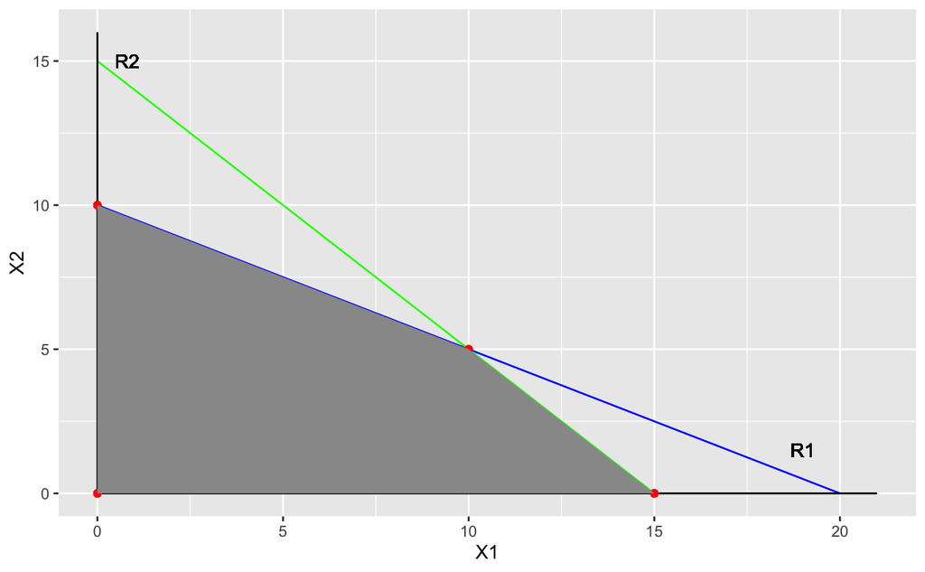

**Evaluación de los posibles puntos óptimos** De los $4$ puntos rojos, solo tenemos tres que son los posibles candidatos a ser solución óptima (el vértice en el origen trivialmente no es solución óptima). Para decidir cual de los tres es, evaluamos en la función objetivo y elegimos el que dé un mayor valor. En efecto:

|  | $x_{1}$ | $x_{2}$ | $Z$ |
| --- | --- | --- | --- |
| $R_{1} -$ Eje Y | $0$ | $10$ | $100.000$ |
| $R_{1} - R_{2}$ | $10$ | $5$ | $130.000$ |
| $R_{2} -$ Eje X | $15$ | $0$ | $120.000$ |

**Interpretación de la solución.** Basados en la solución anterior, se debe producir semanalmente:

$$\begin{array}{ll}
x_{1}^* = 10 \ \ \text{pasteles A} \\
x_{2}^* = \ \ 5 \ \ \text{pasteles B}
\end{array}$$

para así obtener una utilidad máxima semanal de $Z^* = 130.000$ unidades monetarias.

**Análisis de Recursos.** Con base en la solución obtenida se puede calcular cuánto de cada recurso se consume y cuánto de cada recurso sobra; tan solo basta reemplazar los valores de las variables en cada una de las restricciones. En efecto:

| RECURSO | DISPONIBLE | CONSUMO | SOBRANTE |
| --- | --- | --- | --- |
| AZUCAR | $10$ kilos | $0.5*10 + 1*5 = 10$ | $0$ kilos |
| HUEVOS | $120$ unidades | $8*10 + 8*5 = 120$ | $0$ unidades |

# **EJEMPLO 2.**

Una compañía produce tres tipos de productos químicos refinados: $A$, $B$ y $C$. Es necesario producir diariamente al menos $4$ ton de $A$, $2$ ton de $B$ y $1$ ton de $C$. Los productos de entrada son los compuestos $X$ y $Y$. Cada tonelada de $X$ proporciona $0.25$ ton de $A$, $0.25$ ton de $B$ y $0.0834$ ton de $C$. Cada tonelada de $Y$ rinde $0.5$ ton de $A$, $0.10$ ton de $B$ y $0.0834$ ton de $C$. La tonelada de compuesto $X$ cuesta $\$250$ y el compuesto $Y$ $\$400$. El costo de procesamiento es de $\$250$ por ton de $X$ y $\$200$ por ton de $Y$. Las cantidades producidas que excedan los requerimientos diarios no tienen valor, ya que el producto sufre cambios químicos si no se utiliza de inmediato. El problema consiste en determinar la mezcla con costo mínimo de entrada.

1. Plantee el problema como un Problema de Programación Lineal, definiendo claramente las variables de decisión, la función objetivo y las restricciones.
2. Usando el método gráfico, resuelva, analice y concluya.

## SOLUCIÓN.

**Análisis de la información.** Primero se organiza la información en la siguiente tabla.

|  | Compuesto X | Compuesto Y | Disponible |
| --- | --- | --- | --- |
| Producto A | 0.25 | 0.50 | 4 |
| Producto B | 0.25 | 0.10 | 2 |
| Producto C | 0.0834 | 0.0834 | 1 |
| Costo | $500 | $600 |  |

$$\begin{array}{ll}
x_{1}: \ \text{Toneladas de compuesto X.} \\
x_{2}: \ \text{Toneladas de compuesto Y.}
\end{array}$$

**Modelo matemático completo.** El modelo matemático de programación lineal para queda de la siguiente manera:

$$\begin{array}{ll}
\min Z = 500x_{1} + 600x_{2} \\
\text{S.A.} \\
\ \ \ \ 0.25x_{1} + \ \ \ \ 0.50x_{2} \geq 4 \ \text{(toneladas de A)} \\
\ \ \ \ 0.25x_{1} + \ \ \ \ 0.10x_{2} \geq 2 \ \text{(toneladas de B)} \\
0.0834x_{1} + 0.0834x_{2} \geq 1 \ \text{(toneladas de C)} \\
\qquad \ \ \ \ \ \ \ \ \ \ \ \ \ \ \ \ \ x_{1}, x_{2} \geq 0 \ \text{(no negatividad)}
\end{array}$$

**Gráfica de las restricciones.** Se grafican las restricciones asumiendo que se satisface la igualdad en éstas. Es decir, para la primera restricción se tiene:

$$R_{1}: \ \ 0.25x_{1} + 0.50x_{2} = 4$$

Ahora, se buscan los puntos de intersección con los ejes. En efecto:

| $x_{1}$ | $x_{2}$ |
| --- | --- |
| $0$ | $8$ |
| $16$ | $0$ |

A continuación se procede de igual manera con la segunda restricción $R_{2}: \ \ 0.25x_{1} + 0.10x_{2} = 2$. Es decir, se asume la igualdad en la restricción, y se buscan los puntos de intersección con los ejes. Éstos son:

| $x_{1}$ | $x_{2}$ |
| --- | --- |
| $0$ | $20$ |
| $8$ | $0$ |

Lo mismo se hace con la tercera restricción $R_{3}: \ \ 0.0834x_{1} + 0.0834x_{2} = 1$. En efecto:

| $x_{1}$ | $x_{2}$ |
| --- | --- |
| $0$ | $11.990$ |
| $11.990$ | $0$ |

**El área factible de solución corresponderá a la intersección de todas las restricciones. Por lo tanto, hay que encontrar los puntos de intersección entre ellas.** Esto significa resolver el sistema de ecuaciones:

$$\begin{array}{ll}
R_{1}: \qquad \ \ \ \ 0.25x_{1} + \ \ \ \ 0.50x_{2} = 4 \\
R_{2}: \qquad \ \ \ \ 0.25x_{1} + \ \ \ \ 0.10x_{2} = 2 \\
R_{3}: \qquad 0.0834x_{1} + 0.0834x_{2} = 1
\end{array}$$

Luego de resolver, se encuentra los siguientes puntos:

|  | $x_{1}$ | $x_{2}$ |
| --- | --- | --- |
| $R_{1} - R_{2}$ | $6$ | $5$ |
| $R_{1} - R_{3}$ | $7.9808$ | $4.0095$ |
| $R_{2} - R_{3}$ | $5.3397$ | $6.6506$ |

**Gráfica del área factible de solución.** La siguiente gráfica muestra la región factible de solución y los puntos canditatos a ser solución óptima (vértices del área factible).

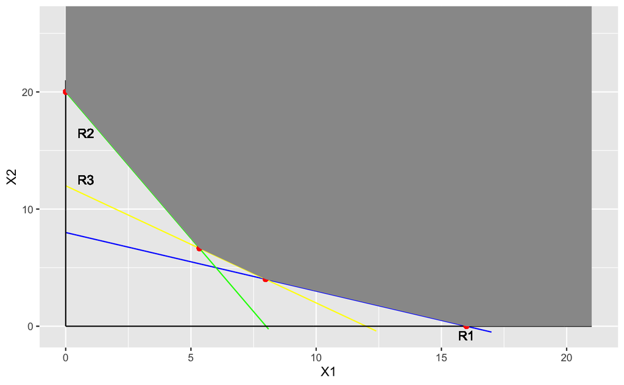

**Evaluación de los posibles puntos óptimos** Tenemos cuatro puntos que son los posibles candidatos a ser solución óptima. Para decidir cual es el óptimo, evaluamos en la función objetivo y elegimos el que dé un menor valor. En efecto:

|  | $x_{1}$ | $x_{2}$ | $Z$ |
| --- | --- | --- | --- |
| $R_{2} -$ Eje Y | $0$ | $20$ | $12.000$ |
| $R_{2} - R_{3}$ | $5.3397$ | $6.6506$ | $6.660,21$ |
| $R_{1} - R_{3}$ | $7.9808$ | $4.0095$ | $6.396,10$ |
| $R_{1} -$ Eje X | $16$ | $0$ | $8.000$ |

$$\begin{array}{ll}
x_{1}^* = 7.9808 \ \ \text{Toneladas de compuesto X} \\
x_{2}^* = 4.0095 \ \ \text{Toneladas de compuesto Y}
\end{array}$$

**Análisis de Recursos.** Con base en la solución obtenida se puede calcular cuánto de cada recurso se consume y cuánto de cada recurso sobra; tan solo basta reemplazar los valores de las variables en cada una de las restricciones. En efecto:

| RECURSO | MINIMO | CONSUMO | DIFERENCIA |
| --- | --- | --- | --- |
| toneladas de A | $4$ | $0.25*7.9808 + 0.50*4.0095 = 4$ | $0$ |
| toneladas de B | $2$ | $0.25*7.9808 + 0.10*4.0095 = 2.39615$ | $0.39615$ |
| toneladas de C | $1$ | $0.0834*7.9808 + 0.0834*4.0095 = 1$ | $0$ |